# Writing Custom Functions in RTMB

## Write a Custom Distribution

- Check first: `RTMB` already has `dlnorm`, `dlgamma`, `dnbinom2`, `dtweedie` and more (see `?RTMB::Distributions`)
- If `RTMB` doesn’t have the distribution you want
- Check `RTMBdist` for additional distributions
- Still want their simulation functionality
- Can write a special function that RTMB will recognize for simulation
- Anything reached with `RTMB:::` is internal to the package and can change between versions

## Example Logit Normal Distribution

- Consider a probability $p$, such that

$$\text{logit}(p) \sim N(\mu, \sigma)$$
- What is the distribution of $p$?

- We need to take into account the distortion caused by the transform

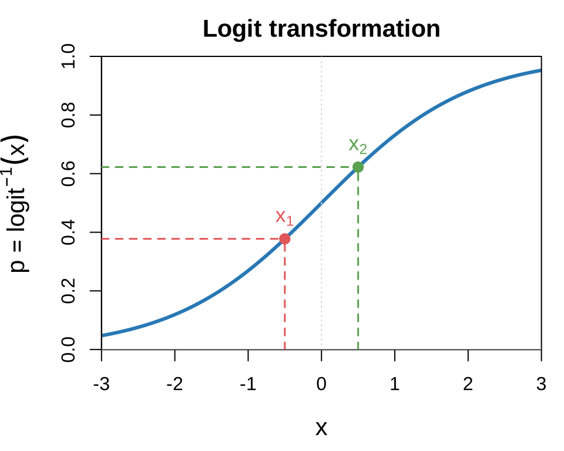

## Logit Normal Distribution

- That change is defined based on the Jacobian.
- For a `logit`, the inverse is

$$\text{logit}^{-1}(x) = p = \frac{\exp(x)}{1+\exp(x)}$$

- The determinant of the Jacobian (in 1D absolute value of derivative)

$$\Big|\frac{dp}{dx}\Big| = p(1-p)$$

- The other direction, it is just the inverse, $\frac{1}{p(1-p)}$
- The distribution of $p$, is then

$$f(p) = \frac{1}{p(1-p)}N(\text{logit}(p), \mu,\sigma)$$

- Through simulation we can confirm

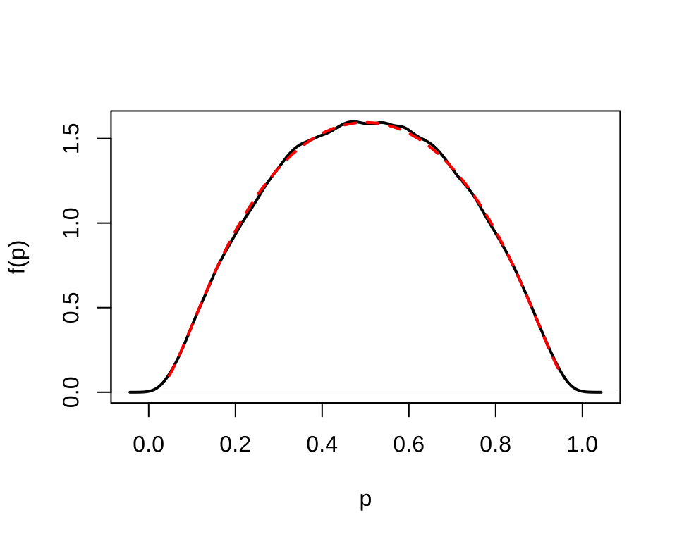

## Log Normal Distribution

- Compare logging the data first as opposed to declaring it log-normal.
- Let’s just look at Chilko sockeye stock recruit.
- For $\log(x) = y$, absolute value of derivative is $1/x$, and $y$ is normally distributed.

```r
library(RTMB)

soxch <- sox %>% filter(PopName == "Chilko")

dlognorm <- function(x, mean, sd, log = FALSE){
  ## Simulation: RTMB passes a 'simref' to be filled in. Check for it first,
  ## before x is used for anything else, then stop.
  if (inherits(x, "simref")) {
    x[] <- rlognorm(length(x), mean, sd)
    return(0)
  }

  y <- log(x)
  logpdens <- dnorm(y, mean, sd, log = TRUE) - y # -y == log(1/x)

  if(log) return(logpdens)
  return(exp(logpdens))
}

rlognorm <- function(n, mean, sd){
  exp(rnorm(n, mean, sd))
}
```

## Log Normal Distribution Cont…

- Does it matter if I include the Jacobian for my observed distribution?

```r
param <- list(logsigma = 0, alpha = 0, logbeta = 0)
soxch$RS <- soxch$recruits/soxch$spawners

## The choice of likelihood is fixed when the function is made. A global on/off
## switch would not be: obj$simulate() and obj$report() re-run the R code later
## and would follow whatever the switch is set to by then.
make_negll <- function(lognormal){
  function(pars){
    getAll(pars, soxch)
    mu <- alpha - exp(logbeta)*spawners
    sigma <- exp(logsigma)
    RS <- OBS(RS)

    if(lognormal){
      nll <- -sum(dlognorm(RS, mu, sigma, log = TRUE))
    }else{
      nll <- -sum(dnorm(log(RS), mu, sigma, log = TRUE))
    }
    return(nll)
  }
}

obj <- MakeADFun(make_negll(lognormal = TRUE), param, silent = TRUE)
obj2 <- MakeADFun(make_negll(lognormal = FALSE), param, silent = TRUE)

obj$fn(obj$par) - obj2$fn(obj2$par)   ## the two differ by a constant:
```

```
[1] 135.8103
```

```r
sum(log(soxch$RS))                      ## the Jacobian term, with no parameters in it
```

```
[1] 135.8103
```

- Same estimates either way.
- The constant matters when models fitted on different scales are compared, for example by AIC.

## Checking Simulation

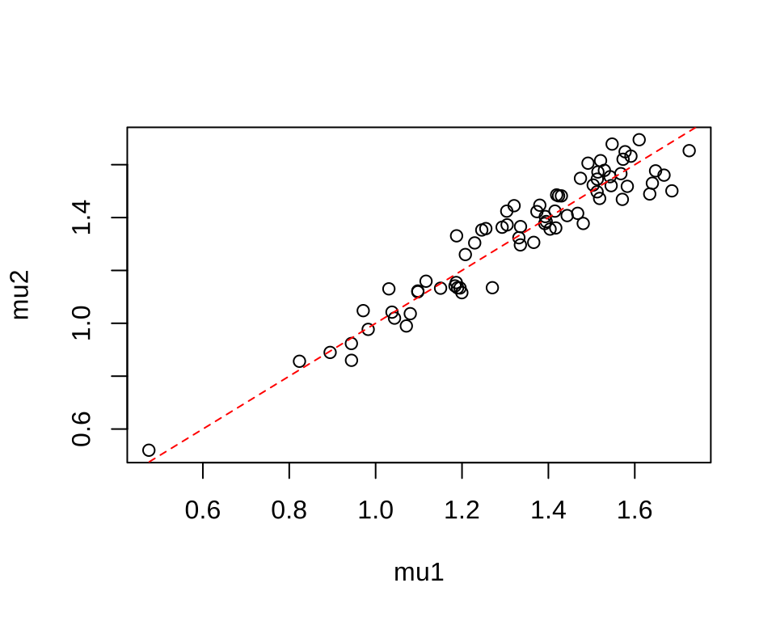

```r
sim1 <- sapply(1:1000, FUN = function(x){obj$simulate(obj$par)$RS})
mu1 <- apply(sim1, 1, mean)

sim2 <- sapply(1:1000, FUN = function(x){obj2$simulate(obj2$par)$RS})
mu2 <- apply(sim2, 1, mean)

plot(mu1, mu2)
abline(0, 1, col = 'red', lty = 2)
```

## When it Matters

- When a Bayesian it is really important (prior distributions)
- Non-normal random effects in a Frequentist perspective
- Consider a Poisson count that depends on a random effect
- If gamma distributed, then that becomes a negative-binomial

$$\begin{align}
\exp(x) & \sim \text{gamma}(a,b) \\
x & \sim \text{gamma}(\exp(x), a, b)\exp(x)
\end{align}$$

```r
## Density of x = log(y) when y is gamma(shape, rate): gamma density times the Jacobian.
## (RTMB has its own dlgamma(x, shape, scale); ours uses a rate, so it gets its own name.)
dloggamma <- function(x, shape, rate, log = FALSE){
  y <- exp(x)
  logpdens <- dgamma(y, shape = shape, rate = rate, log = TRUE) + x

  if(log) return(logpdens)
  return(exp(logpdens))
}

set.seed(10)
lambda <- rgamma(100, 5, 1)
count <- rpois(100, lambda)

make_negll <- function(model){
  function(pars){
    getAll(pars)
    a <- exp(logshape)
    b <- exp(lograte)

    if(model == "negative binomial"){   ## the exact answer: random effect integrated out by hand
      return(-sum(dnbinom(count, a, b/(1+b), log = TRUE)))
    }
    mu <- exp(logre)
    if(model == "with Jacobian"){
      nll <- -sum(dloggamma(logre, a, b, log = TRUE))
    }else{                              ## "without Jacobian"
      nll <- -sum(dgamma(mu, a, b, log = TRUE))
    }
    nll <- nll - sum(dpois(count, mu, log = TRUE))
    return(nll)
  }
}

fit_model <- function(model){
  param <- list(logshape = log(2), lograte = 0)
  random <- NULL
  if(model != "negative binomial"){
    param$logre <- log(count + 0.5)
    random <- "logre"
  }
  obj <- MakeADFun(make_negll(model), param, random = random, silent = TRUE)
  fit <- nlminb(obj$par, obj$fn, obj$gr)
  c(shape = exp(fit$par[["logshape"]]), rate = exp(fit$par[["lograte"]]))
}

## Data were simulated with shape = 5, rate = 1
round(sapply(c("negative binomial", "with Jacobian", "without Jacobian"), fit_model), 2)
```

```
      negative binomial with Jacobian without Jacobian
shape              3.99          4.14             1.81
rate               0.75          0.77             0.42
```

## ADjoint

- Sometimes gradients are slow to compute via AD
- Can be much more efficient than taping to pass the known gradient to RTMB
- In these cases RTMB has `ADjoint` that allows you to provide the function and gradient.
- `ADjoint` Accepts the function eval, `f` and then the gradient `df` as second argument.
- A gradient should have three inputs
  - `x` the input for `f`
  - `y` the output for `f`
  - `dy` the reverse mode derivative that RTMB carries, which is needed for the chain rule
- The `dy` term ensures that the given derivative is passed into the tape.

```r
xsq <- ADjoint(
  \(x){x^2},
  \(x, y, dy){dy*2*x}
)
F <- MakeTape(\(x)log(xsq(x)), 3)
F(3)  ## log(3^2)
```

```
[1] 2.197225
```

```r
F$jacobian(3)   ## 2*3/(3^2)
```

```
          [,1]
[1,] 0.6666667
```

## Lambert W Example

- Lambert W function is computed by approximation, but has an analytical gradient.

$$W(x)e^{W(x)} = x$$

- In this case,

$$\frac{dW(x)}{dx} = \frac{1}{e^{W(x)}(1+W(x))}$$

- Here $W(x)$ is the output of the call to Lambert W, or $y$ for the gradient.

```r
## Numerical Solution (don't worry about it)
W <- function(x) {
  logx <- log(x)
  y <- pmax(logx, 0)
  while (any(abs(logx - log(y) - y) > 1e-9, na.rm = TRUE)) {
      y <- y - (y - exp(logx - y)) / (1 + y)
  }
  y
}
## Derivatives (y = W(x), dy is internal RTMB gradient.)
dW <- function(x, y, dy) {
   dy / (exp(y) * (1 + y))
}
## Define new derivative symbol
LamW <- ADjoint(W, dW)

## Can now use LamW in your own code!
F <- MakeTape(function(x)sum(LamW(x)), numeric(3))
```

- `RTMBdist::lambertW()` is a ready-made version.

## Using It: Reference Points

- For the Ricker model $R = S e^{\alpha - \beta S}$:
  - $S_{max} = 1/\beta$ spawners give the most recruits, and the unfished equilibrium is $\alpha/\beta$
  - $U_{MSY} = 1 - W(e^{1-\alpha})$ and $S_{MSY} = U_{MSY}/\beta$ (Scheuerell 2016)
  - $S_{gen}$, the spawners that return $S_{MSY}$ in one generation, has to be solved numerically
- `ADREPORT` gives every one of them a standard error.

```r
negll_rp <- function(pars){
  getAll(pars, soxch)
  beta <- exp(logbeta)
  mu <- alpha - beta*spawners
  nll <- -sum(dnorm(log(RS), mu, exp(logsigma), log = TRUE))

  Smax <- 1/beta
  Seq <- alpha/beta
  Umsy <- 1 - LamW(exp(1 - alpha))
  Smsy <- Umsy/beta
  ## Sgen/Smsy is between 0 and 1. uniroot() works on the tape (RTMB 1.9 or later),
  ## but its lower and upper limits must be plain numbers, not parameters.
  ratio <- uniroot(\(x){log(x) + alpha - beta*Smsy*x}, lower = 1e-10, upper = 1, tol = 1e-12)$root
  Sgen <- ratio*Smsy
  ADREPORT(Smax); ADREPORT(Seq); ADREPORT(Smsy); ADREPORT(Umsy); ADREPORT(Sgen)
  return(nll)
}

obj <- MakeADFun(negll_rp, list(logsigma = 0, alpha = 1.5, logbeta = 0), silent = TRUE)
fit <- nlminb(obj$par, obj$fn, obj$gr)
round(summary(sdreport(obj), "report"), 3)   ## Chilko, millions of spawners (Umsy is a rate)
```

```
     Estimate Std. Error
Smax    0.388      0.073
Seq     0.936      0.139
Smsy    0.310      0.052
Umsy    0.801      0.024
Sgen    0.030      0.009
```

## Multivariate Logit Normal

- Consider a vector $\mathbf{p}$, such that if we transform it with a multivariate logit,

$$\text{mlogit}(\mathbf{p}) \sim N(\boldsymbol{\mu}, \Sigma).$$

- We might want to do something like this for proportions that are correlated, often for age class data.

```r
## Transformation:
mlogit <- \(x){
  n <- length(x)
  log(x[-n]/x[n])
}
imlogit <- \(x){
  ex <- exp(c(x,0))
  ex/sum(ex)
}

## Density of p: multivariate normal on the mlogit scale, times the Jacobian.
## For this transformation the Jacobian has a simple form: 1/prod(p).
dmvlogitnorm <- function(p, mu, Sigma, log = FALSE){
  logpdens <- dmvnorm(mlogit(p), mu, Sigma, log = TRUE) - sum(log(p))
  if(log) return(logpdens)
  return(exp(logpdens))
}

set.seed(3)
mu <- c(-1, 1)
Sigma <- matrix(c(0.25, -0.1, -0.1, 0.5), nrow=2, ncol=2)
x <- MASS::mvrnorm(1, mu, Sigma)
p <- imlogit(x)
dmvlogitnorm(p, mu, Sigma, log = TRUE)
```

```
[1] 2.283498
```

```r
## Check the Jacobian numerically. The free values are p[1] and p[2]; p[3] = 1 - p[1] - p[2].
J <- MakeTape(\(pf) mlogit(c(pf, 1 - sum(pf))), p[-3])$jacobian(p[-3])
c(numerical = as.numeric(determinant(J)$modulus), closed_form = -sum(log(p)))
```

```
  numerical closed_form
   3.545407    3.545407
```

- `determinant()`, `solve()` and `%*%` work directly on the tape, so no `ADjoint` is needed here.